# Analysis of PCA on CLR

Gati Aher

12/7/2021

Goal: Follow Professor Nicholas Ollberding’s [Introduction to the Statistical Analysis of Microbiome Data in R](https://www.nicholas-ollberding.com/post/introduction-to-the-statistical-analysis-of-microbiome-data-in-r/)

- The diverse goals and technical variation of metagenomic research projects does not allow for a standard “analytic pipeline” for microbiome data analysis.
- Approaching the analysis of microbiome data with a single workflow in mind is generally not a great idea, as there is no “one size fits all” solution for the assorted set of questions one might want to answer.

However, you may be surprised to find that projects on very different topics often have overarching analytic aims such as: * Describing the microbial community composition of a set of samples * Estimating within- and between-sample diversity * Identifying differentially abundant taxa * Predicting a response from a set of taxonomic features * Assessing microbial network structures and patterns of co-occurance * Exploring the phylogenetic relatedness of a set of organisms

ToDo: fix sample metadata?

# Install Packages

```r
.cran_packages <- c("tidyverse", "cowplot", "picante", "vegan", "HMP", "dendextend", "rms", "devtools")
.inst <- .cran_packages %in% installed.packages()
if(any(!.inst)) {
  install.packages(.cran_packages[!.inst])
}
```

```r
.bioc_packages <- c("phyloseq", "DESeq2", "microbiome", "metagenomeSeq", "ALDEx2")
if (!requireNamespace("BiocManager", quietly = TRUE))
  install.packages("BiocManager")
BiocManager::install(.bioc_packages, version = "3.14")
n
```

```r
devtools::install_github("adw96/breakaway")
devtools::install_github("malucalle/selbal")
```

# Loading Required Packages

```r
library(tidyverse); packageVersion("tidyverse")
```

```
[1] ‘1.3.1’
```

```r
library(phyloseq); packageVersion("phyloseq")
```

```
[1] ‘1.38.0’
```

```r
library(DESeq2); packageVersion("DESeq2")
```

```
[1] ‘1.34.0’
```

```r
library(microbiome); packageVersion("microbiome")
```

```
[1] ‘1.16.0’
```

```r
library(vegan); packageVersion("vegan")
```

```
[1] ‘2.5.7’
```

```r
library(picante); packageVersion("picante")
```

```
[1] ‘1.8.2’
```

```r
library(ALDEx2); packageVersion("ALDEx2")
```

```
[1] ‘1.26.0’
```

```r
library(metagenomeSeq); packageVersion("metagenomeSeq")
```

```
[1] ‘1.36.0’
```

```r
library(HMP); packageVersion("HMP")
```

```
[1] ‘2.0.1’
```

```r
library(dendextend); packageVersion("dendextend")
```

```
[1] ‘1.15.2’
```

```r
library(selbal); packageVersion("selbal")
```

```
[1] ‘0.1.0’
```

```r
library(rms); packageVersion("rms")
```

```
[1] ‘6.2.0’
```

```r
library(breakaway); packageVersion("breakaway")
```

```
[1] ‘4.7.6’
```

```r
library(metacoder); packageVersion("metacoder")
```

```
[1] ‘0.3.5’
```

```r
library(taxa); packageVersion("taxa")
```

```
[1] ‘0.4.0’
```

# Initialization

```r
# ggplot2 package theme set
theme_set(theme_bw())
```

# Reading in Phyloseq Data Object

```r
ps <- readRDS("../data/r/phyloseq.rds")
ps
```

```
phyloseq-class experiment-level object
otu_table()   OTU Table:         [ 561 taxa and 86 samples ]
sample_data() Sample Data:       [ 86 samples by 7 sample variables ]
tax_table()   Taxonomy Table:    [ 561 taxa by 7 taxonomic ranks ]
phy_tree()    Phylogenetic Tree: [ 561 tips and 559 internal nodes ]
```

```r
ps %>%
  sample_data %>%
  dplyr::count(carbon)
```

```
$carbon
[1] "cellulose" "glucose"   "malate"    "original"

$n
[1] 61 12 12  1

attr(,"row.names")
[1] 1 2 3 4
attr(,".S3Class")
[1] "data.frame"
attr(,"class")
[1] "sample_data"
attr(,"class")attr(,"package")
[1] "phyloseq"
```

```r
ps_cellulose <- readRDS("../data/r/phyloseq_cellulose.rds")
ps_cellulose
```

```
phyloseq-class experiment-level object
otu_table()   OTU Table:         [ 558 taxa and 61 samples ]
sample_data() Sample Data:       [ 61 samples by 7 sample variables ]
tax_table()   Taxonomy Table:    [ 558 taxa by 7 taxonomic ranks ]
phy_tree()    Phylogenetic Tree: [ 558 tips and 556 internal nodes ]
```

# Visualize Relative Abundances

```r
#Get count of class
table(phyloseq::tax_table(ps)[, "class"])
```

```
     actinobacteria alphaproteobacteria             bacilli       bacteroidetes         bacteroidia  betaproteobacteria           chlorobia          clostridia          cytophagia
                  7                 271                  10                   3                  85                  17                   6                  14                  24
deltaproteobacteria       fibrobacteria      flavobacteriia       fusobacteriia gammaproteobacteria    gemmatimonadetes            opitutae    sphingobacteriia        spirochaetia
                  3                   2                   3                   1                  33                   3                  66                   1                  12
```

```r
#Get count of species
table(phyloseq::tax_table(ps)[, "order"])
```

```
                       actinomycetales                          aeromonadales                    alphaproteobacteria                             bacillales                          bacteroidales
                                     7                                      1                                      1                                      5                                     85
bacteroidetes order ii. incertae sedis                        burkholderiales                        caulobacterales                           chlorobiales                           chromatiales
                                     3                                      6                                      4                                      6                                      1
                         clostridiales                           cytophagales                     desulfovibrionales                      enterobacteriales                        fibrobacterales
                                    14                                     24                                      3                                     20                                      2
                      flavobacteriales                        fusobacteriales                       gemmatimonadales                        lactobacillales                        methylococcales
                                     3                                      1                                      3                                      5                                      1
                          neisseriales                             opitutales                        pseudomonadales                            rhizobiales                          rhodocyclales
                                     2                                     66                                      7                                    191                                      9
                      rhodospirillales                     sphingobacteriales                       sphingomonadales                         spirochaetales                        xanthomonadales
                                    73                                      1                                      2                                     12                                      3
```

```r
#Convert to relative abundance
ps_rel_abund = phyloseq::transform_sample_counts(ps, function(x){x / sum(x)})
phyloseq::otu_table(ps)[1:5, 1:5]
```

```
OTU Table:          [5 taxa and 5 samples]
                     taxa are rows
        sC0C s1C03A s1C03B s1C05A s1C05B
OTU_471    8      4      7      5      7
OTU_620   61     34     41     32     79
OTU_640 4270   2662   3657   2136   4412
OTU_403    5      3      2      1      1
OTU_162    1      1      0      1      0
```

```r
phyloseq::otu_table(ps_rel_abund)[1:5, 1:5]
```

```
OTU Table:          [5 taxa and 5 samples]
                     taxa are rows
                sC0C       s1C03A       s1C03B       s1C05A       s1C05B
OTU_471 9.078117e-05 5.550930e-05 5.953596e-05 5.977715e-05 5.657251e-05
OTU_620 6.922064e-04 4.718290e-04 3.487106e-04 3.825738e-04 6.384612e-04
OTU_640 4.845445e-02 3.694144e-02 3.110329e-02 2.553680e-02 3.565685e-02
OTU_403 5.673823e-05 4.163197e-05 1.701027e-05 1.195543e-05 8.081788e-06
OTU_162 1.134765e-05 1.387732e-05 0.000000e+00 1.195543e-05 0.000000e+00
```

```r
sample_data(ps_rel_abund)$day
```

```
 [1] 10 3  3  5  5  7  7  10 10 20 20 3  3  5  5  10 10 3  3  3  5  5  5  7  7  7  10 10 10 3  3  3  5  5  7  7  10 10 10 3  3  3  5  5  5  7  7  7  10 10 10 3  3  3  5  5  5  7  7  7  10 10 10 3
[65] 3  3  5  5  5  7  7  7  10 10 10 3  3  3  5  5  5  7  7  7  10 10
Levels: 3 5 7 10 20
```

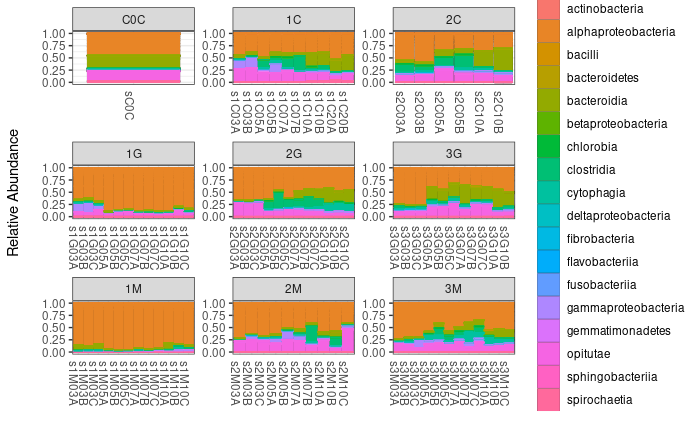

```r
# Plot class
phyloseq::plot_bar(ps_rel_abund, fill = "class") +
  geom_bar(aes(color = class, fill = class), stat = "identity", position = "stack") +
  labs(x = "", y = "Relative Abundance\n") +
  facet_wrap(~factor(group, levels=c("C0C", "1C", "2C", "1G", "2G", "3G", "1M", "2M", "3M")), scales = "free") +
  theme(panel.background = element_blank(),
        axis.ticks.x=element_blank())
```

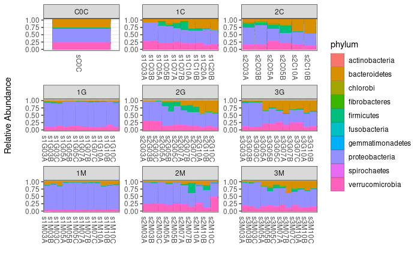

```r
# Plot phylum
phyloseq::plot_bar(ps_rel_abund, fill = "phylum") +
  geom_bar(aes(color = phylum, fill = phylum), stat = "identity", position = "stack") +
  labs(x = "", y = "Relative Abundance\n") +
  facet_wrap(~factor(group, levels=c("C0C", "1C", "2C", "1G", "2G", "3G", "1M", "2M", "3M")), scales = "free") +
  theme(panel.background = element_blank(),
        axis.ticks.x=element_blank())
```